# Tooth Growth dataset

Sergio Giraldo

June, 2019

## Summary

In this project the tooth growth dataset will be analyzed using hypothesis tests.

ToothGrowth data set contains the result from an experiment studying the effect of vitamin C on tooth growth in 60 Guinea pigs.

Each animal received one of three dose levels of vitamin C (0.5, 1, and 2 mg/day) by one of two delivery methods, (orange juice (coded as *OJ*) or ascorbic acid (a form of vitamin C and coded as *VC*).

## Analysis

### Load libraries

```r
library(ggplot2)
library(psych)
```

### Loading the data

```r
data(ToothGrowth)
```

### Exploring the data

Structure of the data:

```r
dim(ToothGrowth)
```

```
## [1] 60  3
```

```r
str(ToothGrowth)
```

```
## 'data.frame':    60 obs. of  3 variables:
##  $ len : num  4.2 11.5 7.3 5.8 6.4 10 11.2 11.2 5.2 7 ...
##  $ supp: Factor w/ 2 levels "OJ","VC": 2 2 2 2 2 2 2 2 2 2 ...
##  $ dose: num  0.5 0.5 0.5 0.5 0.5 0.5 0.5 0.5 0.5 0.5 ...
```

```r
describe(ToothGrowth)
```

```
##       vars  n  mean   sd median trimmed  mad min  max range  skew kurtosis
## len      1 60 18.81 7.65  19.25   18.95 9.04 4.2 33.9  29.7 -0.14    -1.04
## supp*    2 60  1.50 0.50   1.50    1.50 0.74 1.0  2.0   1.0  0.00    -2.03
## dose     3 60  1.17 0.63   1.00    1.15 0.74 0.5  2.0   1.5  0.37    -1.55
##         se
## len   0.99
## supp* 0.07
## dose  0.08
```

The column `supp` is a factor containing two levels:

- OJ
- VC

Are there any missing data?

```r
sum(is.na(ToothGrowth))
```

```
## [1] 0
```

There are no missing values.

How the head of the data looks like:

```r
head(ToothGrowth)
```

```
##    len supp dose
## 1  4.2   VC  0.5
## 2 11.5   VC  0.5
## 3  7.3   VC  0.5
## 4  5.8   VC  0.5
## 5  6.4   VC  0.5
## 6 10.0   VC  0.5
```

Let’s see the teeth growth by the dosage

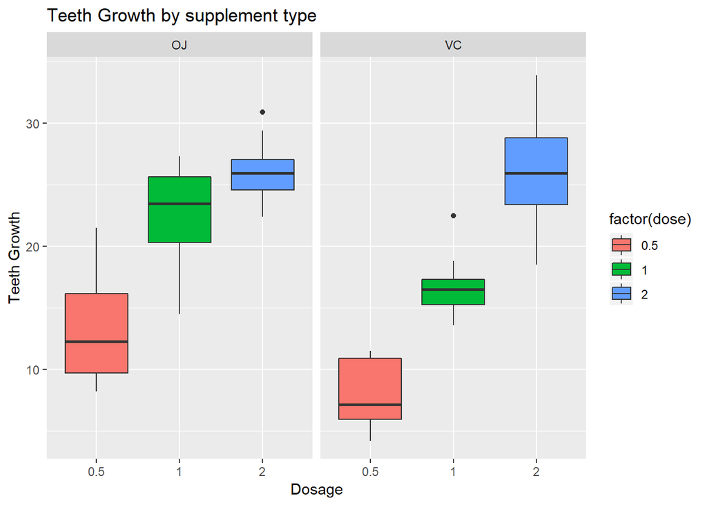

```r
ggplot(ToothGrowth, aes(x=factor(dose), y=len, fill=factor(dose))) +
  geom_boxplot() +
  facet_grid(.~supp) +
  xlab("Dosage") +
  ylab("Teeth Growth") +
  ggtitle("Teeth Growth by supplement type")
```

This analysis show us that the dosage affects the tooth length, the larger the dosage, the longer the tooth.

### Confidence intervals and hypothesis testing

This section tries to answer the question if there is a correllation between the tooth growth and the supplement dosage.

#### Assumptions

- The variables must be independent and identically distributed (i.i.d.);
- Variances of tooth growth are different when using different supplement and dosage;
- Tooth growth follows a normal distribution.

#### Dosage as factor

Let our null hypothesis to be `there is no difference in tooth growth between dosage`.

Let our alternate hypothesis to be `there are more tooth growth when the dosage increases`.

```r
dose_05 <-subset(ToothGrowth, dose %in% c(0.5, 1.0))
dose_1 <-subset(ToothGrowth, dose %in% c(0.5, 2.0))
dose_2 <-subset(ToothGrowth, dose %in% c(1.0, 2.0))
```

Let’s run the test on each subset

```r
t.test(len~dose, data=dose_05, paired=FALSE, conf.level = 0.95)
```

```
##
##  Welch Two Sample t-test
##
## data:  len by dose
## t = -6.4766, df = 37.986, p-value = 1.268e-07
## alternative hypothesis: true difference in means is not equal to 0
## 95 percent confidence interval:
##  -11.983781  -6.276219
## sample estimates:
## mean in group 0.5   mean in group 1
##            10.605            19.735
```

```r
t.test(len~dose, data=dose_1, paired=FALSE, conf.level = 0.95)
```

```
##
##  Welch Two Sample t-test
##
## data:  len by dose
## t = -11.799, df = 36.883, p-value = 4.398e-14
## alternative hypothesis: true difference in means is not equal to 0
## 95 percent confidence interval:
##  -18.15617 -12.83383
## sample estimates:
## mean in group 0.5   mean in group 2
##            10.605            26.100
```

```r
t.test(len~dose, data=dose_2, paired=FALSE, conf.level = 0.95)
```

```
##
##  Welch Two Sample t-test
##
## data:  len by dose
## t = -4.9005, df = 37.101, p-value = 1.906e-05
## alternative hypothesis: true difference in means is not equal to 0
## 95 percent confidence interval:
##  -8.996481 -3.733519
## sample estimates:
## mean in group 1 mean in group 2
##          19.735          26.100
```

In All 3 cases, the p-values (1.268e-07, 1.906e-05, 4.398e-14) are close to 0,lower than 0.05 (the default value for the tolerance of the error alpha), and the null hypothesis is rejected.

That can be interpreted as that is very likely that dosage has effect, and higher dosages casuses higher tooth growth.

#### Supplement as factor

Let our null hypothesis to be `there is no difference in tooth growth when using the supplement OJ and VC`.

Let our alternate hypothesis to be `there are more tooth growth when using supplement OJ than VC`.

```r
# split data set, it doesnt matter the dosage
OJ <- ToothGrowth$len[ToothGrowth$supp == 'OJ']
VC <- ToothGrowth$len[ToothGrowth$supp == 'VC']
```

Let’s run the test on each subset

```r
t.test(OJ, VC, alternative = "two.sided", paired = FALSE, var.equal = FALSE, conf.level = 0.95)
```

```
##
##  Welch Two Sample t-test
##
## data:  OJ and VC
## t = 1.9153, df = 55.309, p-value = 0.06063
## alternative hypothesis: true difference in means is not equal to 0
## 95 percent confidence interval:
##  -0.1710156  7.5710156
## sample estimates:
## mean of x mean of y
##  20.66333  16.96333
```

As the p-value (0.06063) is greater than 0.05 (the default value for the tolerance of the error alpha), the null hypothesis can’t be rejected.